# Customer Behavior and Shopping Habits

This dataset is from Kaggle and is freely available under the CC0 Public Domain License.

##### Dataset

The Consumer Behavior and Shopping Habits dataset offers in-depth insights into the preferences, tendencies, and patterns that consumers exhibit during their shopping experiences. This dataset includes a wide array of variables, covering demographic details, purchase history, product preferences, shopping frequency, and both online and offline shopping behaviors. This data has no missing values.

## Problem Statement

1. What is the total number of customers in the dataset?
2. What is the distribution of male to female customers?
3. How many identifiable customer segments are there in this dataset?
4. What are the characteristics of our high-spending customers?
5. Which cluster has the highest number of customers?

```python
#import libraries
import numpy as np
import pandas as pd
import seaborn as sns
import matplotlib.pyplot as plt
```

```python
from sklearn.preprocessing import LabelEncoder
from sklearn.preprocessing import StandardScaler,normalize
from sklearn.decomposition import PCA
from yellowbrick.cluster import KElbowVisualizer
from sklearn.cluster import KMeans
from mpl_toolkits.mplot3d import Axes3D
from sklearn.cluster import AgglomerativeClustering
from matplotlib.colors import ListedColormap
from sklearn import metrics
import warnings
import sys
```

## Read the Dataset

```python
df = pd.read_csv("shopping_behavior_updated.csv")
df.head(2)
```

|  | Customer ID | Age | Gender | Item Purchased | Category | Purchase Amount (USD) | Location | Size | Color | Season | Review Rating | Subscription Status | Shipping Type | Discount Applied | Promo Code Used | Previous Purchases | Payment Method | Frequency of Purchases |
| --- | --- | --- | --- | --- | --- | --- | --- | --- | --- | --- | --- | --- | --- | --- | --- | --- | --- | --- |
| 0 | 1 | 55 | Male | Blouse | Clothing | 53 | Kentucky | L | Gray | Winter | 3.1 | Yes | Express | Yes | Yes | 14 | Venmo | Fortnightly |
| 1 | 2 | 19 | Male | Sweater | Clothing | 64 | Maine | L | Maroon | Winter | 3.1 | Yes | Express | Yes | Yes | 2 | Cash | Fortnightly |

### Total Number of Customers in dataset

```python
cust = df['Customer ID'].nunique()
print(f"There are {cust} unique customers in our dataset" )
```

```
There are 3900 unique customers in our dataset
```

```python
df.shape
```

```
(3900, 18)
```

```python
df.info()
```

```
<class 'pandas.core.frame.DataFrame'>
RangeIndex: 3900 entries, 0 to 3899
Data columns (total 18 columns):
 #   Column                  Non-Null Count  Dtype
---  ------                  --------------  -----
 0   Customer ID             3900 non-null   int64
 1   Age                     3900 non-null   int64
 2   Gender                  3900 non-null   object
 3   Item Purchased          3900 non-null   object
 4   Category                3900 non-null   object
 5   Purchase Amount (USD)   3900 non-null   int64
 6   Location                3900 non-null   object
 7   Size                    3900 non-null   object
 8   Color                   3900 non-null   object
 9   Season                  3900 non-null   object
 10  Review Rating           3900 non-null   float64
 11  Subscription Status     3900 non-null   object
 12  Shipping Type           3900 non-null   object
 13  Discount Applied        3900 non-null   object
 14  Promo Code Used         3900 non-null   object
 15  Previous Purchases      3900 non-null   int64
 16  Payment Method          3900 non-null   object
 17  Frequency of Purchases  3900 non-null   object
dtypes: float64(1), int64(4), object(13)
memory usage: 548.6+ KB
```

### Distribution of male to female customers

```python
dist = df.groupby('Gender')['Customer ID'].nunique()
print(f"The distribution of male to female customers is: {dict(dist)}")
```

```
The distribution of male to female customers is: {'Female': 1248, 'Male': 2652}
```

## Encode Categorical Data

```python
# List categorical data
s = (df.dtypes == 'object')
cat=list(s[s].index)
cat
```

```
['Gender',
 'Item Purchased',
 'Category',
 'Location',
 'Size',
 'Color',
 'Season',
 'Subscription Status',
 'Shipping Type',
 'Discount Applied',
 'Promo Code Used',
 'Payment Method',
 'Frequency of Purchases']
```

```python
label_encoders = {}
for col in cat:
    le = LabelEncoder()
    df[col] = le.fit_transform(df[col].astype(str))
    label_encoders[col] = le
df.head(2)
```

|  | Customer ID | Age | Gender | Item Purchased | Category | Purchase Amount (USD) | Location | Size | Color | Season | Review Rating | Subscription Status | Shipping Type | Discount Applied | Promo Code Used | Previous Purchases | Payment Method | Frequency of Purchases |
| --- | --- | --- | --- | --- | --- | --- | --- | --- | --- | --- | --- | --- | --- | --- | --- | --- | --- | --- |
| 0 | 1 | 55 | 1 | 2 | 1 | 53 | 16 | 0 | 7 | 3 | 3.1 | 1 | 1 | 1 | 1 | 14 | 5 | 3 |
| 1 | 2 | 19 | 1 | 23 | 1 | 64 | 18 | 0 | 12 | 3 | 3.1 | 1 | 1 | 1 | 1 | 2 | 1 | 3 |

```python
df.info()
```

```
<class 'pandas.core.frame.DataFrame'>
RangeIndex: 3900 entries, 0 to 3899
Data columns (total 18 columns):
 #   Column                  Non-Null Count  Dtype
---  ------                  --------------  -----
 0   Customer ID             3900 non-null   int64
 1   Age                     3900 non-null   int64
 2   Gender                  3900 non-null   int32
 3   Item Purchased          3900 non-null   int32
 4   Category                3900 non-null   int32
 5   Purchase Amount (USD)   3900 non-null   int64
 6   Location                3900 non-null   int32
 7   Size                    3900 non-null   int32
 8   Color                   3900 non-null   int32
 9   Season                  3900 non-null   int32
 10  Review Rating           3900 non-null   float64
 11  Subscription Status     3900 non-null   int32
 12  Shipping Type           3900 non-null   int32
 13  Discount Applied        3900 non-null   int32
 14  Promo Code Used         3900 non-null   int32
 15  Previous Purchases      3900 non-null   int64
 16  Payment Method          3900 non-null   int32
 17  Frequency of Purchases  3900 non-null   int32
dtypes: float64(1), int32(13), int64(4)
memory usage: 350.5 KB
```

## Standardize Data

```python
scaler = StandardScaler()
scaler.fit(df)
scaled_df=pd.DataFrame(scaler.transform(df), columns=df.columns)
print("All columns are scaled")
```

```
All columns are scaled
```

```python
scaled_df.head(2)
```

|  | Customer ID | Age | Gender | Item Purchased | Category | Purchase Amount (USD) | Location | Size | Color | Season | Review Rating | Subscription Status | Shipping Type | Discount Applied | Promo Code Used | Previous Purchases | Payment Method | Frequency of Purchases |
| --- | --- | --- | --- | --- | --- | --- | --- | --- | --- | --- | --- | --- | --- | --- | --- | --- | --- | --- |
| 0 | -1.731607 | 0.718913 | 0.685994 | -1.394144 | -0.002002 | -0.285629 | -0.576399 | -1.203814 | -0.707620 | 1.349198 | -0.907584 | 1.644294 | -0.892178 | 1.151339 | 1.151339 | -0.785831 | 1.471636 | 0.012575 |
| 1 | -1.730719 | -1.648629 | 0.685994 | 1.523236 | -0.002002 | 0.178852 | -0.436944 | -1.203814 | -0.015163 | 1.349198 | -0.907584 | 1.644294 | -0.892178 | 1.151339 | 1.151339 | -1.616552 | -0.894631 | 0.012575 |

## Decode Data

```python
for col in cat:
    le = label_encoders[col]
    df[col] = le.inverse_transform(df[col])

df.head(2)
```

|  | Customer ID | Age | Gender | Item Purchased | Category | Purchase Amount (USD) | Location | Size | Color | Season | Review Rating | Subscription Status | Shipping Type | Discount Applied | Promo Code Used | Previous Purchases | Payment Method | Frequency of Purchases |
| --- | --- | --- | --- | --- | --- | --- | --- | --- | --- | --- | --- | --- | --- | --- | --- | --- | --- | --- |
| 0 | 1 | 55 | Male | Blouse | Clothing | 53 | Kentucky | L | Gray | Winter | 3.1 | Yes | Express | Yes | Yes | 14 | Venmo | Fortnightly |
| 1 | 2 | 19 | Male | Sweater | Clothing | 64 | Maine | L | Maroon | Winter | 3.1 | Yes | Express | Yes | Yes | 2 | Cash | Fortnightly |

## Elbow Visualizer

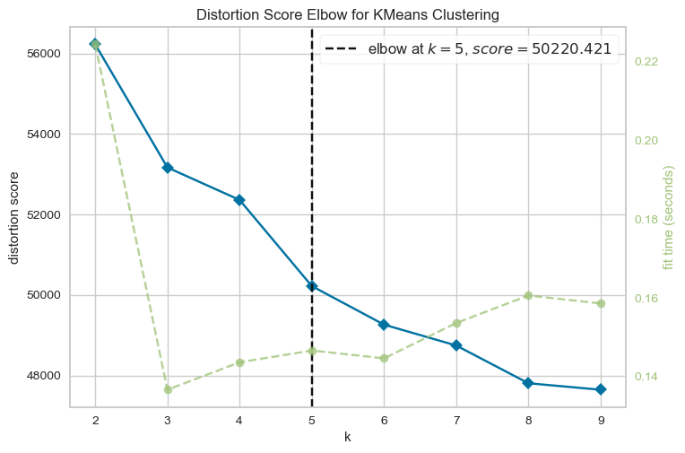

```python
Elbow_M = KElbowVisualizer(KMeans(n_init='auto'), k=(2,10))
Elbow_M.fit(scaled_df)
Elbow_M.show()
```

## Agglomerative Clustering

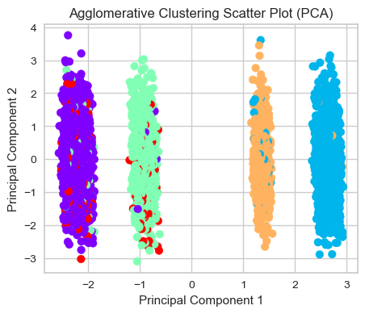

```python
ac = AgglomerativeClustering(n_clusters=5)

cluster_assignments = ac.fit_predict(scaled_df)

# Reduce dimensionality
pca = PCA(n_components=2)
pca_result = pca.fit_transform(scaled_df)

# Scatter plot
plt.figure(figsize=(5, 4))
plt.scatter(pca_result[:, 0], pca_result[:, 1], c=cluster_assignments, cmap='rainbow')
plt.xlabel("Principal Component 1")
plt.ylabel("Principal Component 2")
plt.title("Agglomerative Clustering Scatter Plot (PCA)")
plt.show()
```

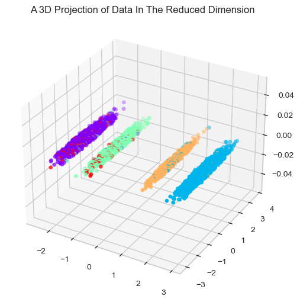

```python
x = pca_result[:, 0]
y = pca_result[:, 1]
# 3D scatter plot
fig = plt.figure(figsize=(8,6))
ax = fig.add_subplot(111, projection="3d")
ax.scatter(x,y, c=cluster_assignments, marker="o" , cmap='rainbow')
ax.set_title("A 3D Projection of Data In The Reduced Dimension")
plt.show()
```

## Explore Clusters

```python
df['clusters'] = cluster_assignments
```

## Customer Distribution Across Clusters

The highest customer count are in clusters 0 and 1

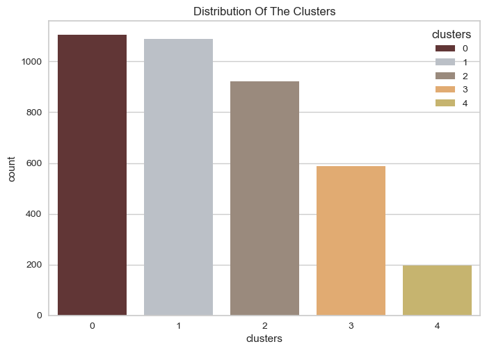

```python
pal = ["#682F2F","#B9C0C9", "#9F8A78","#F3AB60", "#D4BC60"]
pl = sns.countplot(data=df,x="clusters",hue='clusters', palette= pal)
pl.set_title("Distribution Of The Clusters")
plt.show()
```

## Age Group Categorization

```python
bins = [0, 29, 39, 49,59, 80]
labels = ['18-29', '30-39', '40-49', '50-59', '60-80']
df['age_group'] = pd.cut(df['Age'], bins=bins, labels=labels, right=False)

df.head()
```

|  | Customer ID | Age | Gender | Item Purchased | Category | Purchase Amount (USD) | Location | Size | Color | Season | Review Rating | Subscription Status | Shipping Type | Discount Applied | Promo Code Used | Previous Purchases | Payment Method | Frequency of Purchases | clusters | age_group |
| --- | --- | --- | --- | --- | --- | --- | --- | --- | --- | --- | --- | --- | --- | --- | --- | --- | --- | --- | --- | --- |
| 0 | 1 | 55 | Male | Blouse | Clothing | 53 | Kentucky | L | Gray | Winter | 3.1 | Yes | Express | Yes | Yes | 14 | Venmo | Fortnightly | 1 | 50-59 |
| 1 | 2 | 19 | Male | Sweater | Clothing | 64 | Maine | L | Maroon | Winter | 3.1 | Yes | Express | Yes | Yes | 2 | Cash | Fortnightly | 1 | 18-29 |
| 2 | 3 | 50 | Male | Jeans | Clothing | 73 | Massachusetts | S | Maroon | Spring | 3.1 | Yes | Free Shipping | Yes | Yes | 23 | Credit Card | Weekly | 1 | 50-59 |
| 3 | 4 | 21 | Male | Sandals | Footwear | 90 | Rhode Island | M | Maroon | Spring | 3.5 | Yes | Next Day Air | Yes | Yes | 49 | PayPal | Weekly | 1 | 18-29 |
| 4 | 5 | 45 | Male | Blouse | Clothing | 49 | Oregon | M | Turquoise | Spring | 2.7 | Yes | Free Shipping | Yes | Yes | 31 | PayPal | Annually | 1 | 40-49 |

```python
df['age_group'].unique()
```

```
['50-59', '18-29', '40-49', '60-80', '30-39']
Categories (5, object): ['18-29' < '30-39' < '40-49' < '50-59' < '60-80']
```

## Heatmap of Clusters by Age Groups

Among the age groups, Cluster 4 shows the smallest customer count.

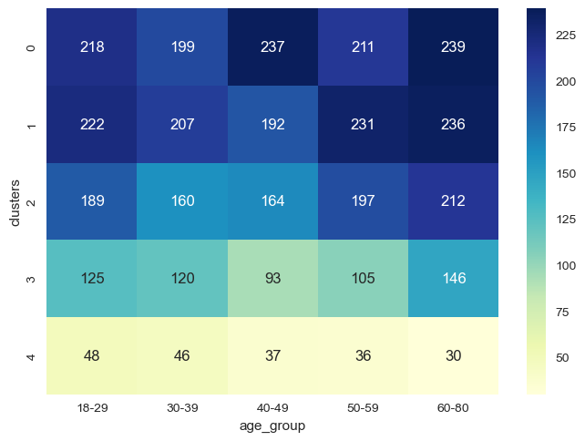

```python
ct = pd.crosstab(df['clusters'], df['age_group'])
sns.heatmap(ct, annot=True, cmap="YlGnBu", fmt='g')
plt.show()
```

## Purchase Analysis by Cluster: Identifying High-Spending Category

Cluster 4, despite having fewer customers, is surpassing the other categories in terms of spending.

```python
threshold = df['Purchase Amount (USD)'].quantile(0.75)
df_high_spender = df[df['Purchase Amount (USD)']>threshold]
```

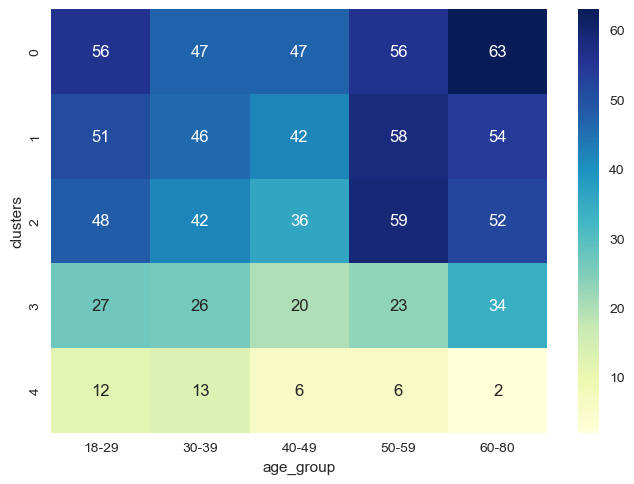

```python
ct = pd.crosstab(df_high_spender['clusters'], df_high_spender['age_group'])
sns.heatmap(ct, annot=True, cmap="YlGnBu", fmt='g')
plt.show()
```

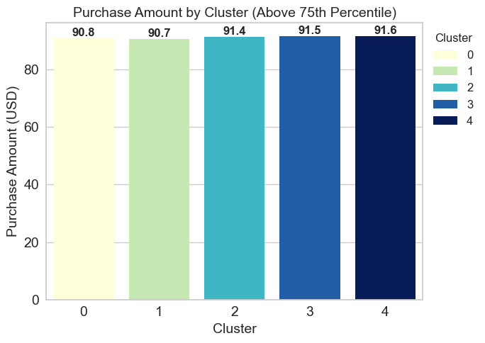

```python
plt.figure(figsize=(7, 5))

ax = sns.barplot(data=df_high_spender, x='clusters', y='Purchase Amount (USD)', hue='clusters',
                 linewidth=2, saturation=1, errorbar=None, palette="YlGnBu")

for container in ax.containers:
    ax.bar_label(container, fmt='%.1f', label_type='edge', fontsize=12, weight='bold')

plt.title('Purchase Amount by Cluster (Above 75th Percentile)', fontsize=14)
plt.ylabel('Purchase Amount (USD)', fontsize=14)
plt.xlabel('Cluster', fontsize=14)
plt.tick_params(axis='both', which='major', labelsize=14)
plt.legend(title='Cluster', bbox_to_anchor=(1, 1), loc='upper left', fontsize=12)

plt.tight_layout()
plt.show()
```

## Visualizing Average Payment Amount by Category in Cluster 4

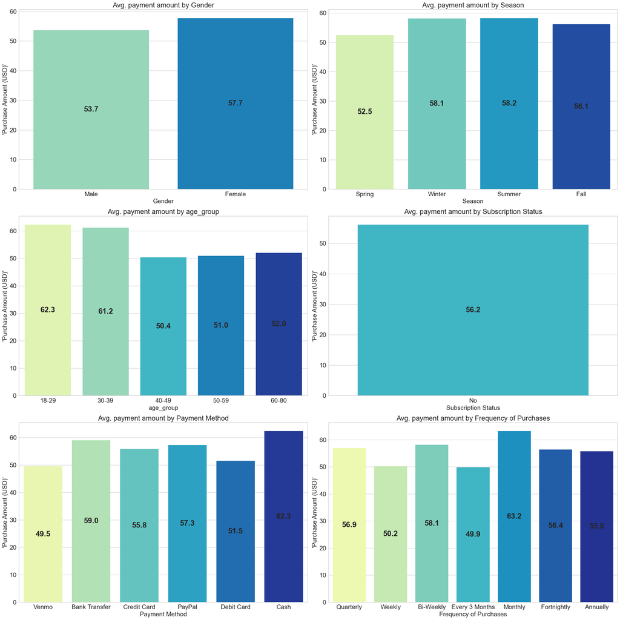

```python
#Get cluster 4 dataframe
df4 = df[df['clusters']==4]

fig, axes = plt.subplots(nrows=3, ncols=2, figsize=(25, 25))
axes = axes.flatten()
new_cat = ['Gender','Season', 'age_group', 'Subscription Status','Payment Method','Frequency of Purchases']
for i, column in enumerate(new_cat):
    ax = axes[i]
    ax.set_title(f'Avg. payment amount by {column}', fontsize=20)
    s = sns.barplot(data=df4, y='Purchase Amount (USD)',x=column ,ax=ax,hue=column,
                      linewidth=2, saturation=1, errorbar=None,palette="YlGnBu")
    for container in ax.containers:
        ax.bar_label(container, fmt='%.1f', label_type='center', fontsize=22, weight='bold')

    ax.set_ylabel("'Purchase Amount (USD)'", fontsize=18)
    ax.set_xlabel(ax.get_xlabel(), fontsize=18)
    ax.tick_params(axis='both', which='major', labelsize=18)
plt.tight_layout()
plt.show()
```

## Purchase Amount Distribution in Cluster 4 Across Age Groups and Gender

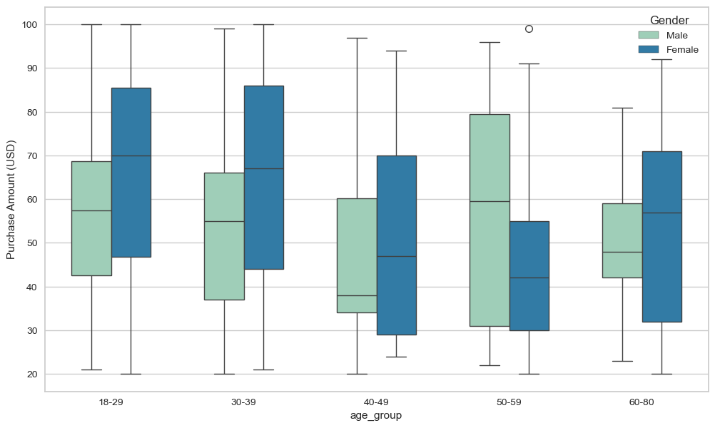

```python
plt.figure(figsize=(12, 7))
sns.boxplot(data=df4, y="Purchase Amount (USD)", x="age_group", hue="Gender", width=0.6, palette="YlGnBu")
plt.show()
```

## Summary

1. The dataset comprises 3,900 unique customers.
2. The gender distribution among buyers is in the ratio of 17:8, with 17 male buyers for every 8 female buyers.
3. The dataset reveals the presence of five distinct customer segments.
4. Notably, none of our high-spending customers hold a subscription. The highest average payment amount is associated with customers who opt for cash payments, and the peak average payment comes from customers making monthly purchases.
5. Cluster 0 is the most populous segment, consisting of 1,104 customers, constituting 28.31% of the total customer base. It stands out as the cluster with the highest customer count.